# Regression models and win expectancy

```r
library(tidyverse)
library(broom)

library(Lahman)
```

As I write this (2018-07-04) the Seattle Mariners are sitting in second place in the American League West, with a winning percentage of .640 and half a game behind the defending World Series champion Houston Astros.

The Mariners’ relatively small run differential (i.e. how many more runs they have scored than allowed) has been noted all season;

- at the end of the first month of the season Jake Mailhot (@jakemailhot) at Lookout Landing wrote [“Just how lucky have the Mariners been?”](https://www.lookoutlanding.com/2018/5/1/17308386/mariners-cluster-luck-april-run-differential);
- on May 25, Sports Illustrated carried an article [“The Mariners Have Been Very Lucky, But They May Also Be Pretty Good”](https://www.si.com/mlb/2018/05/25/seattle-mariners-al-west)

*at the end of May (2018-05-29) John Trupin (@JohnTrupin) on the same site wrote [“The Mariners aren’t the first team built on a run differential-beating bullpen”](https://www.lookoutlanding.com/2018/5/29/17406204/the-mariners-arent-the-first-team-built-on-a-run-differential-beating-bullpen-diaz-colome-nicasio).

This seems like a good time to look at the first and simplest of the measures of “win expectation” that have burbled up in the Sabremetric community over the years; the other approaches may be worthy of consideration for a future post.

And for the earlier seasons, we’ll rely on the [`Lahman` package](https://cran.r-project.org/web/packages/Lahman/).

## Pythagorean win ratio

Bill James, the godfather of Sabermetrics, developed the Pythagorean win expectation model ([wikipedia page](https://en.wikipedia.org/wiki/Pythagorean_expectation)). The basic idea is that there is a relationship between the runs a team scores ($RS$) and allows ($RA$), and the proportion of the games that they can be expected to win ($WE$). The equation is expressed thus:

$$WE = RS^2 / (RS^2 + RA^2)$$

FanGraphs [“BaseRuns” page](https://www.fangraphs.com/depthcharts.aspx?position=BaseRuns)

- [Pythagorean Win-Loss](https://www.fangraphs.com/library/principles/expected-wins-and-losses/)
- [Pythagorean Win-Loss](https://www.fangraphs.com/library/team-record-pythagorean-record-and-base-runs/)
- See also [“BaseRuns” definition](https://www.fangraphs.com/library/features/baseruns/) for alternative measure

### function

```r
winexp_fun <- function(RS, RA) {
  winratio <- RS^2 / (RS^2 + RA^2)
}
```

test

```r
RS <- 4.43
RA <- 4.18


winexp_fun(RS, RA)
```

## Empirical test

```r
data(Teams)

head(Teams)
```

```
##   yearID lgID teamID franchID divID Rank  G Ghome  W  L DivWin WCWin LgWin
## 1   1871   NA    BS1      BNA  <NA>    3 31    NA 20 10   <NA>  <NA>     N
## 2   1871   NA    CH1      CNA  <NA>    2 28    NA 19  9   <NA>  <NA>     N
## 3   1871   NA    CL1      CFC  <NA>    8 29    NA 10 19   <NA>  <NA>     N
## 4   1871   NA    FW1      KEK  <NA>    7 19    NA  7 12   <NA>  <NA>     N
## 5   1871   NA    NY2      NNA  <NA>    5 33    NA 16 17   <NA>  <NA>     N
## 6   1871   NA    PH1      PNA  <NA>    1 28    NA 21  7   <NA>  <NA>     Y
##   WSWin   R   AB   H X2B X3B HR BB SO SB CS HBP SF  RA  ER  ERA CG SHO SV
## 1  <NA> 401 1372 426  70  37  3 60 19 73 NA  NA NA 303 109 3.55 22   1  3
## 2  <NA> 302 1196 323  52  21 10 60 22 69 NA  NA NA 241  77 2.76 25   0  1
## 3  <NA> 249 1186 328  35  40  7 26 25 18 NA  NA NA 341 116 4.11 23   0  0
## 4  <NA> 137  746 178  19   8  2 33  9 16 NA  NA NA 243  97 5.17 19   1  0
## 5  <NA> 302 1404 403  43  21  1 33 15 46 NA  NA NA 313 121 3.72 32   1  0
## 6  <NA> 376 1281 410  66  27  9 46 23 56 NA  NA NA 266 137 4.95 27   0  0
##   IPouts  HA HRA BBA SOA   E DP    FP                    name
```

[output cut: 20 more lines]

```r
Teams_sel <- Teams %>%
  filter(yearID > 1961) %>%
  rename(RS = R) %>%
  mutate(winpct = W / G)

Teams_sel <- Teams_sel %>%
  mutate(winexp = winexp_fun(RS, RA))


head(Teams_sel)
```

```
##   yearID lgID teamID franchID divID Rank   G Ghome  W   L DivWin WCWin
## 1   1962   AL    BAL      BAL  <NA>    7 162    82 77  85   <NA>  <NA>
## 2   1962   AL    BOS      BOS  <NA>    8 160    79 76  84   <NA>  <NA>
## 3   1962   AL    CHA      CHW  <NA>    5 162    81 85  77   <NA>  <NA>
## 4   1962   NL    CHN      CHC  <NA>    9 162    81 59 103   <NA>  <NA>
## 5   1962   NL    CIN      CIN  <NA>    3 162    81 98  64   <NA>  <NA>
## 6   1962   AL    CLE      CLE  <NA>    6 162    81 80  82   <NA>  <NA>
##   LgWin WSWin  RS   AB    H X2B X3B  HR  BB   SO SB CS HBP SF  RA  ER  ERA
## 1     N     N 652 5491 1363 225  34 156 516  931 45 32  NA NA 680 599 3.69
## 2     N     N 707 5530 1429 257  53 146 525  923 39 33  NA NA 756 674 4.22
## 3     N     N 707 5514 1415 250  56  92 620  674 76 40  NA NA 658 601 3.73
## 4     N     N 632 5534 1398 196  56 126 504 1044 78 50  NA NA 827 725 4.54
## 5     N     N 802 5645 1523 252  40 167 498  903 66 39  NA NA 685 608 3.75
## 6     N     N 682 5484 1341 202  22 180 502  939 35 16  NA NA 745 663 4.14
##   CG SHO SV IPouts   HA HRA BBA SOA   E  DP    FP              name
```

[output cut: 20 more lines]

#### plot

Use ggplot2 to look at the relationship between the Pythagorean estimate and the true value.

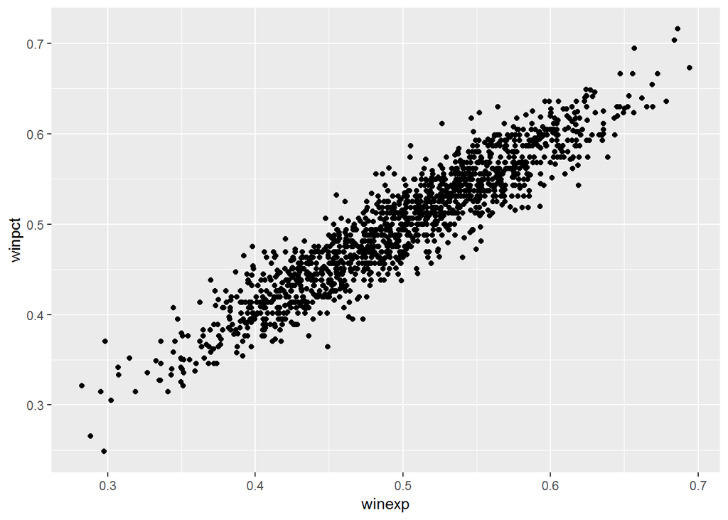

```r
ggplot(data = Teams_sel) +
  geom_point(mapping = aes(x = winexp, y = winpct))
```

#### The regression model

```r
winexp_mod <- lm(winexp ~ winpct, Teams_sel)

print(winexp_mod)
```

```
##
## Call:
## lm(formula = winexp ~ winpct, data = Teams_sel)
##
## Coefficients:
## (Intercept)       winpct
##     0.02844      0.94421
```

```r
summary(winexp_mod)
```

```
##
## Call:
## lm(formula = winexp ~ winpct, data = Teams_sel)
##
## Residuals:
##      Min       1Q   Median       3Q      Max
## -0.07998 -0.01713 -0.00020  0.01650  0.07760
##
## Coefficients:
##             Estimate Std. Error t value Pr(>|t|)
## (Intercept) 0.028440   0.004751   5.986 2.71e-09 ***
## winpct      0.944214   0.009416 100.274  < 2e-16 ***
## ---
## Signif. codes:  0 '***' 0.001 '**' 0.01 '*' 0.05 '.' 0.1 ' ' 1
##
## Residual standard error: 0.02526 on 1456 degrees of freedom
## Multiple R-squared:  0.8735, Adjusted R-squared:  0.8734
## F-statistic: 1.005e+04 on 1 and 1456 DF,  p-value: < 2.2e-16
```

#### Residuals

Use `broom`

David Robinson, 2015-03-19, [“broom: a package for tidying statistical models into data frames”](https://www.r-bloggers.com/broom-a-package-for-tidying-statistical-models-into-data-frames/)

- also https://cran.r-project.org/web/packages/broom/vignettes/broom.html

```r
tidy(winexp_mod)
```

```
##          term   estimate   std.error  statistic      p.value
## 1 (Intercept) 0.02843987 0.004751235   5.985784 2.707391e-09
## 2      winpct 0.94421443 0.009416343 100.274010 0.000000e+00
```

```r
glance(winexp_mod)
```

```
##   r.squared adj.r.squared      sigma statistic p.value df   logLik
## 1 0.8735109     0.8734241 0.02526047  10054.88       0  2 3295.462
##         AIC      BIC  deviance df.residual
## 1 -6584.925 -6569.07 0.9290613        1456
```

```r
head(augment(winexp_mod))
```

```
##      winexp    winpct   .fitted      .se.fit       .resid         .hat
## 1 0.4789883 0.4753086 0.4772331 0.0007001570  0.001755119 0.0007682595
## 2 0.4665447 0.4750000 0.4769417 0.0007011142 -0.010397015 0.0007703613
## 3 0.5358512 0.5246914 0.5238610 0.0007022909  0.011990219 0.0007729494
## 4 0.3686924 0.3641975 0.3723204 0.0014368935 -0.003628047 0.0032356844
## 5 0.5781978 0.6049383 0.5996313 0.0011918173 -0.021433512 0.0022260574
## 6 0.4559373 0.4938272 0.4947186 0.0006638248 -0.038781279 0.0006905959
##       .sigma      .cooksd  .std.resid
## 1 0.02526911 1.857272e-06  0.06950753
## 2 0.02526768 6.535340e-05 -0.41175085
## 3 0.02526720 8.720953e-05  0.47484681
## 4 0.02526897 3.359031e-05 -0.14385837
## 5 0.02526289 8.049071e-04 -0.84944598
## 6 0.02524868 8.149956e-04 -1.53578576
```

The Pythagorean model explains a lot of the variation: the R-squared value of 0.8735109

Idea: filter where .se.fit is poor (i.e. big residual), plot – see where the 2018 Mariners sit on the list

https://drsimonj.svbtle.com/visualising-residuals

#### `ggplot2 3.0.0`

This also seemed like a good time to take [the latest version of `ggplot2` (3.0.0)](https://www.tidyverse.org/articles/2018/07/ggplot2-3-0-0/) for a test run.

#### `ggeffects` package

Daniel Lüdecke, 2018-07-04, [“Marginal Effects for Regression Models in R”](https://www.r-bloggers.com/marginal-effects-for-regression-models-in-r-rstats-dataviz/)